# R e visualização

Lista avaliativa 1 – Probabilidade e Estatística

Wagner Martins de Lima Filho

22/09/2023

# 1 Leitura e limpeza dos dados

Primeiramente, utilizaremos a função `head()` para ter uma noção das informações contidas no arquivo `.tsv` escolhido.

```r
df <- read_tsv('2004-2021.tsv')
df %>% head(3)
```

| DATA INICIAL | DATA FINAL | REGIÃO | ESTADO | PRODUTO | NÚMERO DE POSTOS PESQUISADOS | UNIDADE DE MEDIDA | PREÇO MÉDIO REVENDA | DESVIO PADRÃO REVENDA | PREÇO MÍNIMO REVENDA | PREÇO MÁXIMO REVENDA | MARGEM MÉDIA REVENDA | COEF DE VARIAÇÃO REVENDA | PREÇO MÉDIO DISTRIBUIÇÃO | DESVIO PADRÃO DISTRIBUIÇÃO | PREÇO MÍNIMO DISTRIBUIÇÃO | PREÇO MÁXIMO DISTRIBUIÇÃO | COEF DE VARIAÇÃO DISTRIBUIÇÃO |
| --- | --- | --- | --- | --- | --- | --- | --- | --- | --- | --- | --- | --- | --- | --- | --- | --- | --- |
| 2004-05-09 | 2004-05-15 | CENTRO OESTE | DISTRITO FEDERAL | ETANOL HIDRATADO | 127 | R$/l | 1.288 | 0.016 | 1.19 | 1.350 | 0.463 | 0.012 | 0.825 | 0.11 | 0.4201 | 0.9666 | 0.133 |
| 2004-05-09 | 2004-05-15 | CENTRO OESTE | GOIAS | ETANOL HIDRATADO | 387 | R$/l | 1.162 | 0.114 | 0.89 | 1.449 | 0.399 | 0.098 | 0.763 | 0.088 | 0.5013 | 1.05 | 0.115 |
| 2004-05-09 | 2004-05-15 | CENTRO OESTE | MATO GROSSO | ETANOL HIDRATADO | 192 | R$/l | 1.389 | 0.097 | 1.18 | 1.760 | 0.419 | 0.070 | 0.97 | 0.095 | 0.5614 | 1.161 | 0.098 |

Pode-se obserar algumas informações importantes quanto ao formato:

- As colunas estão bem comportadas quanto ao formato *tibble*, pois não há informações sendo apresentadas nas colunas.

```r
df <- df %>% tibble()
```

- As colunas e algumas informações encontram-se em caixa alta e acentuadas, logo uma boa prática seria utilizar o `janitor::clean_names()` para renomear as colunas em um formato melhor em termos de código, além disso usaremos o `mutate()` para deixar as informações em caixa baixa.

```r
df <- janitor::clean_names(df)
df <- df %>% mutate(
  regiao = str_to_title(regiao),
  estado = str_to_title(estado),
  produto = str_to_sentence(produto)
)
```

- Algumas colunas que deveriam ser do tipo `<dbl>` estão no formato `<chr>`, logo utilizando novamente a função `mutate`, podemos ajustar as informações para o formato correto.

```r
df <- df %>% mutate(
  margem_media_revenda = as.double(margem_media_revenda),
  preco_medio_distribuicao = as.double(preco_medio_distribuicao),
  desvio_padrao_distribuicao = as.double(desvio_padrao_distribuicao),
  preco_minimo_distribuicao = as.double(preco_minimo_distribuicao),
  preco_maximo_distribuicao = as.double(preco_maximo_distribuicao),
  coef_de_variacao_distribuicao = as.double(coef_de_variacao_distribuicao)
  )
```

Portanto, após as primeiras impressões, obtemos o seguinte tibble:

| data_inicial | data_final | regiao | estado | produto | numero_de_postos_pesquisados | unidade_de_medida | preco_medio_revenda | desvio_padrao_revenda | preco_minimo_revenda | preco_maximo_revenda | margem_media_revenda | coef_de_variacao_revenda | preco_medio_distribuicao | desvio_padrao_distribuicao | preco_minimo_distribuicao | preco_maximo_distribuicao | coef_de_variacao_distribuicao |
| --- | --- | --- | --- | --- | --- | --- | --- | --- | --- | --- | --- | --- | --- | --- | --- | --- | --- |
| 2004-05-09 | 2004-05-15 | Centro Oeste | Distrito Federal | Etanol hidratado | 127 | R$/l | 1.288 | 0.016 | 1.190 | 1.350 | 0.463 | 0.012 | 0.825 | 0.110 | 0.42010 | 0.96660 | 0.133 |
| 2004-05-09 | 2004-05-15 | Centro Oeste | Goias | Etanol hidratado | 387 | R$/l | 1.162 | 0.114 | 0.890 | 1.449 | 0.399 | 0.098 | 0.763 | 0.088 | 0.50130 | 1.05000 | 0.115 |
| 2004-05-09 | 2004-05-15 | Centro Oeste | Mato Grosso | Etanol hidratado | 192 | R$/l | 1.389 | 0.097 | 1.180 | 1.760 | 0.419 | 0.070 | 0.970 | 0.095 | 0.56140 | 1.16100 | 0.098 |
| 2004-05-09 | 2004-05-15 | Centro Oeste | Mato Grosso Do Sul | Etanol hidratado | 162 | R$/l | 1.262 | 0.070 | 1.090 | 1.509 | 0.432 | 0.055 | 0.830 | 0.119 | 0.59910 | 1.22242 | 0.143 |
| 2004-05-09 | 2004-05-15 | Nordeste | Alagoas | Etanol hidratado | 103 | R$/l | 1.181 | 0.078 | 1.050 | 1.400 | 0.240 | 0.066 | 0.941 | 0.077 | 0.74410 | 1.03170 | 0.082 |
| 2004-05-09 | 2004-05-15 | Nordeste | Bahia | Etanol hidratado | 408 | R$/l | 1.383 | 0.132 | 0.999 | 2.050 | 0.426 | 0.095 | 0.957 | 0.128 | 0.56860 | 1.35000 | 0.134 |
| 2004-05-09 | 2004-05-15 | Nordeste | Ceara | Etanol hidratado | 278 | R$/l | 1.453 | 0.218 | 1.030 | 1.950 | 0.353 | 0.150 | 1.100 | 0.068 | 0.73320 | 1.29400 | 0.062 |
| 2004-05-09 | 2004-05-15 | Nordeste | Maranhao | Etanol hidratado | 105 | R$/l | 1.631 | 0.158 | 1.350 | 2.000 | 0.515 | 0.097 | 1.116 | 0.091 | 0.99230 | 1.36183 | 0.082 |
| 2004-05-09 | 2004-05-15 | Nordeste | Paraiba | Etanol hidratado | 125 | R$/l | 1.284 | 0.130 | 1.100 | 1.699 | 0.353 | 0.101 | 0.931 | 0.072 | 0.75770 | 1.29720 | 0.077 |
| 2004-05-09 | 2004-05-15 | Nordeste | Pernambuco | Etanol hidratado | 423 | R$/l | 1.224 | 0.141 | 0.989 | 1.700 | 0.277 | 0.115 | 0.947 | 0.091 | 0.56430 | 1.35410 | 0.096 |

[output cut: 9990 more lines]

# 2 Análise Exploratória

É importante verificar a quantidade de `NA's` em algumas colunas importantes como preço médio de revenda, datas iniciais de análise e localidade.

```r
df %>% count(
  is.na(preco_medio_revenda),
  is.na(data_inicial),
  is.na(regiao),
  is.na(estado)
  )
```

| is.na(preco_medio_revenda) | is.na(data_inicial) | is.na(regiao) | is.na(estado) | n |
| --- | --- | --- | --- | --- |
| FALSE | FALSE | FALSE | FALSE | 120823 |

- A coluna produtos apresenta mais de um tipo para o mesmo produto, logo deveríamos agrupar valores que deveriam pertencer à mesma classificação.

```r
df %>% group_by(produto) %>% summarize()
```

| produto |
| --- |
| Etanol hidratado |
| Gasolina aditivada |
| Gasolina comum |
| Glp |
| Gnv |
| Oleo diesel |
| Oleo diesel s10 |
| Óleo diesel |
| Óleo diesel s10 |

Então, realizamos algumas manobras para mudar estes valores:

```r
df <- df %>% mutate(
  produto = ifelse(produto == 'Óleo diesel', 'Oleo diesel', produto),
  produto = ifelse(produto == 'Óleo diesel s10', 'Oleo diesel s10', produto)
)
```

Tendo em vista que não foram encontrados casos de `NA` e agora os dados encontram-se bem comportados, partiremos para a análise visual e inferências de alguns comportamentos a fim de responder à algumas questões, como: quais regiões, ou estados possuem os combustíveis históricamente mais caros, mais baratos e existiria algum padrão para isso?

# 3 Visualização

A fim de responder as perguntas anteriores, trabalharemos na visualização e tentaremos traçar alguns padrões de comportamento.

Não foi possível apresentar os gráficos com caracteres especiais do português nos gráficos.

## 3.1 *Scatter plots*

Primeiramente, tentaremos visualizar a distribuição geral das informações contidas na amostra.

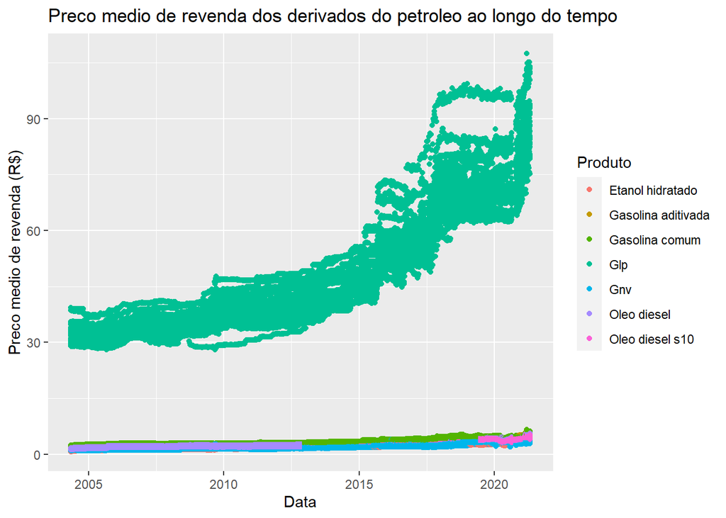

```r
df %>% ggplot(
  aes(
    x = data_inicial,
    y = preco_medio_revenda,
    color = produto
  )) +
  geom_point() +
  labs(
    title = 'Preco medio de revenda dos derivados do petroleo ao longo do tempo',
    x = "Data",
    y = "Preco medio de revenda (R$)",
    color = "Produto"
  )
```

Pode-se perceber que o **glp** no geral apresenta um preço mais elevado, por conta da venda ser realizada em uma unidade de medida diferente, dificultando a comparação com outros produtos. Portanto, vamos ignorá-lo por um momento.

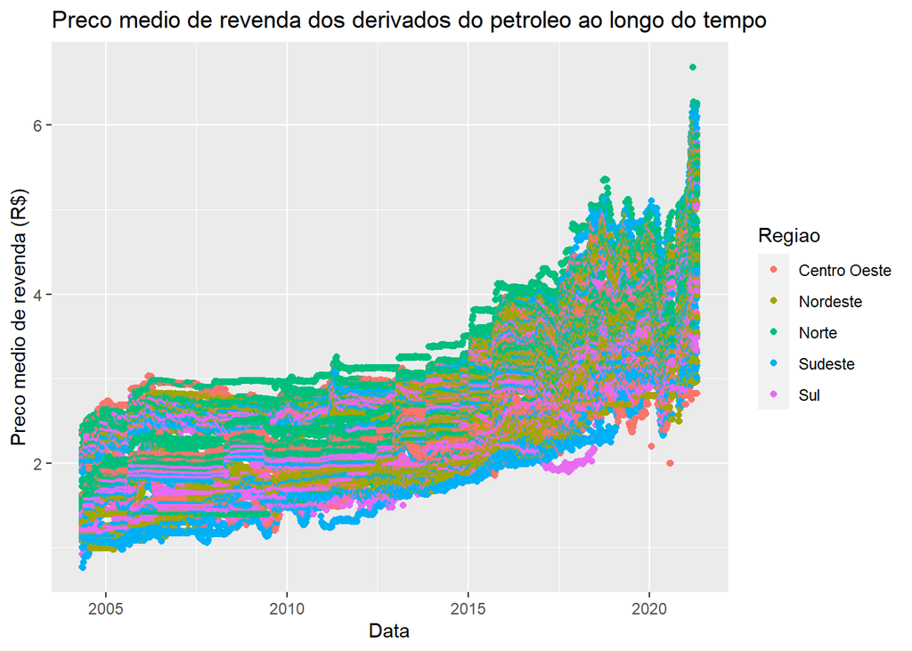

```r
df_sem_glp <- df %>% filter((!produto=='Glp'))
df_sem_glp %>% ggplot(
  aes(
    x = data_inicial,
    y = preco_medio_revenda,
    color = regiao,
  )) +
  geom_point() +
  labs(
    title = 'Preco medio de revenda dos derivados do petroleo ao longo do tempo',
    x = "Data",
    y = "Preco medio de revenda (R$)",
    color = "Regiao"
  )
```

Agora, podemos ver que embora desorganizado, os dados estão distribuídos de forma mais uniforme e podemos utilizar o `geom_smooth()` para evitar sobrecarga de informações apresentadas.

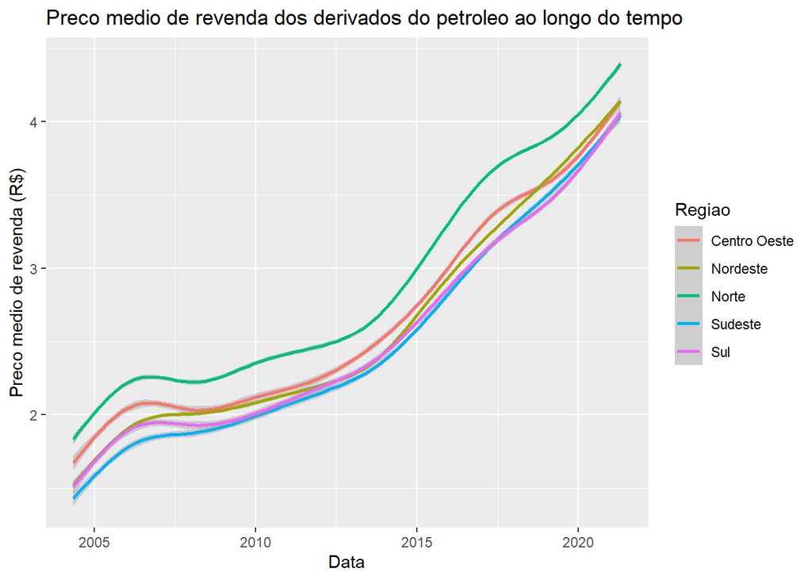

```r
df_sem_glp %>% ggplot(
  aes(
    x = data_inicial,
    y = preco_medio_revenda,
    color = regiao
  )) +
  geom_smooth() +
  labs(
    title = 'Preco medio de revenda dos derivados do petroleo ao longo do tempo',
    x = "Data",
    y = "Preco medio de revenda (R$)",
    color = "Regiao"
  )
```

Pode-se observar que a região norte possui a maior média de preço de combustíveis, enquanto o sudeste que concentra a produção e refino dos produtos, possui a média mais baixa. Desta forma, pode-se inferir que o fator geográfico envolvido no custo de transporte desses produtos possui uma forte influência no valor de revenda.

Também iremos nos aproximar do sudeste para poder entender um pouco mais da dinâmica de preços em nossa região.

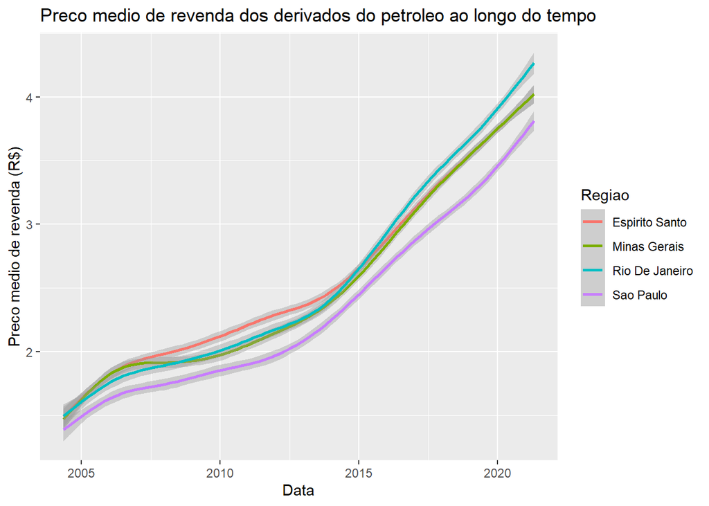

```r
df_sem_glp %>% filter(regiao == 'Sudeste') %>% ggplot(aes(
  x = data_inicial,
  y = preco_medio_revenda,
  color = estado
)) +
  geom_smooth() +
  labs(
    title = 'Preco medio de revenda dos derivados do petroleo ao longo do tempo',
    x = "Data",
    y = "Preco medio de revenda (R$)",
    color = "Regiao"
  )
```

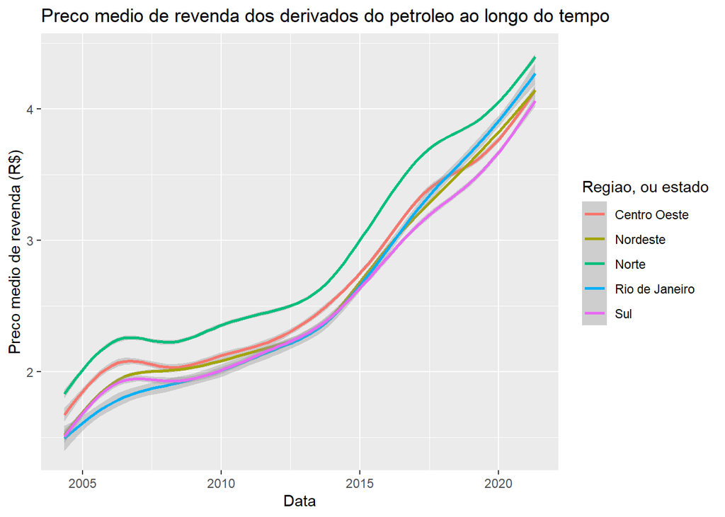

```r
df_sem_glp %>% filter(regiao != 'Sudeste' | estado == 'Rio De Janeiro') %>% mutate(
  regiao = ifelse(regiao != 'Sudeste', regiao, 'Rio de Janeiro')
) %>% ggplot(aes(
  x = data_inicial,
  y = preco_medio_revenda,
  color = regiao
)) +
  geom_smooth() +
  labs(
    title = 'Preco medio de revenda dos derivados do petroleo ao longo do tempo',
    x = "Data",
    y = "Preco medio de revenda (R$)",
    color = "Regiao, ou estado"
  )
```

## 3.2 Histogramas

Utilizaremos o histograma para analisar mais de perto a distribuicao de preco entre a regiao e o estado analisado.

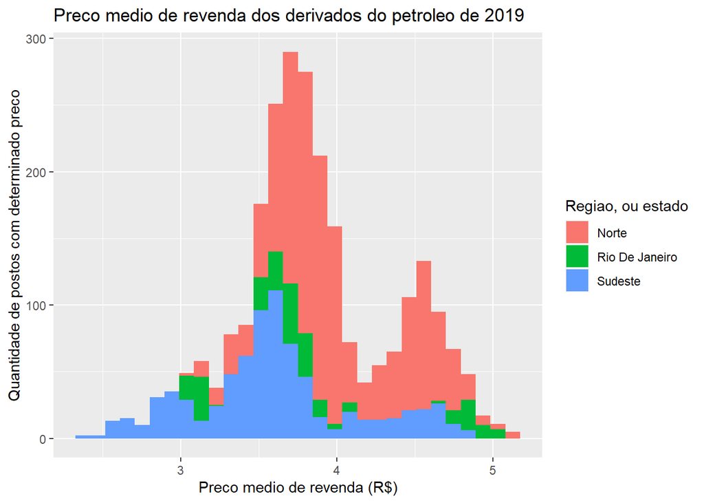

```r
df_sem_glp_2019 <- df_sem_glp %>% filter(regiao == 'Sudeste' | regiao == 'Norte', data_inicial > '2019-01-01' & data_inicial < '2020-01-01')

df_sem_glp_2019 %>% mutate(
    regiao = ifelse(estado == 'Rio De Janeiro', 'Rio De Janeiro', regiao)
  ) %>% ggplot(aes(
    x = preco_medio_revenda,
    fill = regiao
  )) + geom_histogram() +
  labs(
    title = 'Preco medio de revenda dos derivados do petroleo de 2019',
    x = "Preco medio de revenda (R$)",
    y = "Quantidade de postos com determinado preco",
    fill = "Regiao, ou estado"
  )
```

## 3.3 *Box plots*

Com os *Box plots*, é possível perceber alguns *outliers* que podem ser traduzidos como pontos isolados no ano em que uma determinada política de preço, ou alteração inesperada gerou algum impacto no mercado dos derivados de petróleo.

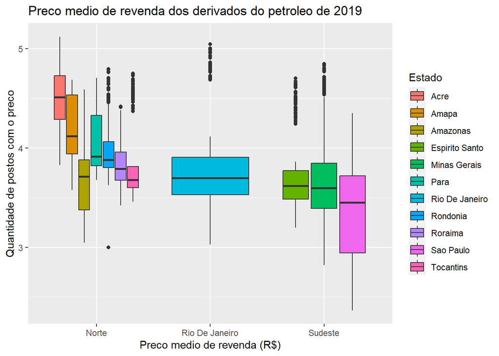

```r
df_sem_glp_2019 %>% mutate(
    regiao = ifelse(estado == 'Rio De Janeiro', 'Rio De Janeiro', regiao)
  ) %>% ggplot(aes(
    x = regiao,
    y = preco_medio_revenda,
    fill = estado
  )) + geom_boxplot() +
  labs(
    title = 'Preco medio de revenda dos derivados do petroleo de 2019',
    x = "Preco medio de revenda (R$)",
    y = "Quantidade de postos com o preco",
    fill = "Estado"
  )
```

Por conta do dataset ser empregado de preços e valores temporais, não houve uma relação para uma visualização justa e compreensível que requeira um gráfico de barras, mas que em oposição, pôde ser muito bem representado em linhas, tendo em vista uma evolução dos preços e indicação de comportamentos futuros.

## 3.4 Gráficos de linha

Aqui pode-se ver o avanço do preço dos derivados do petróleo para o estado do Rio de Janeiro e como se tem um avanço próximo a exponencial.

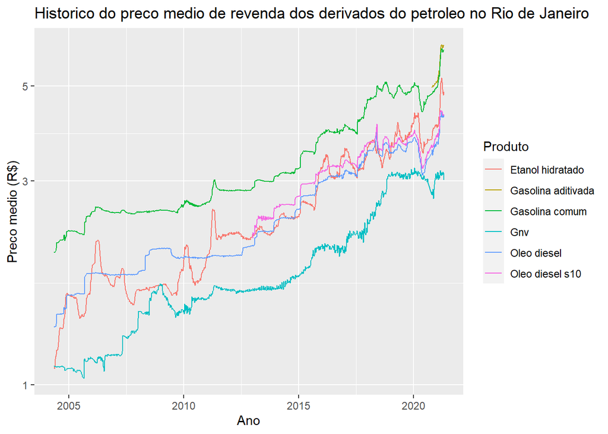

```r
df_sem_glp %>% filter(
  estado == "Rio De Janeiro"
  ) %>% ggplot(aes(
    x = data_inicial,
    y = preco_medio_revenda,
    color = produto,
  )) + geom_line() + scale_y_log10() +
  labs(
    title = 'Historico do preco medio de revenda dos derivados do petroleo no Rio de Janeiro',
    x = "Ano",
    y = "Preco medio (R$)",
    color = "Produto"
  )
```

Agora vemos como a evolução dos preços do Rio de Janeiro (maior valor no Sudeste) possui comportamento muito similar à evolução dos preços em São Paulo (menor valor no Sudeste), o quê indica que apesar da discrepância nos valores de revenda, a sua taxa de crescimento tem caminhado junto.

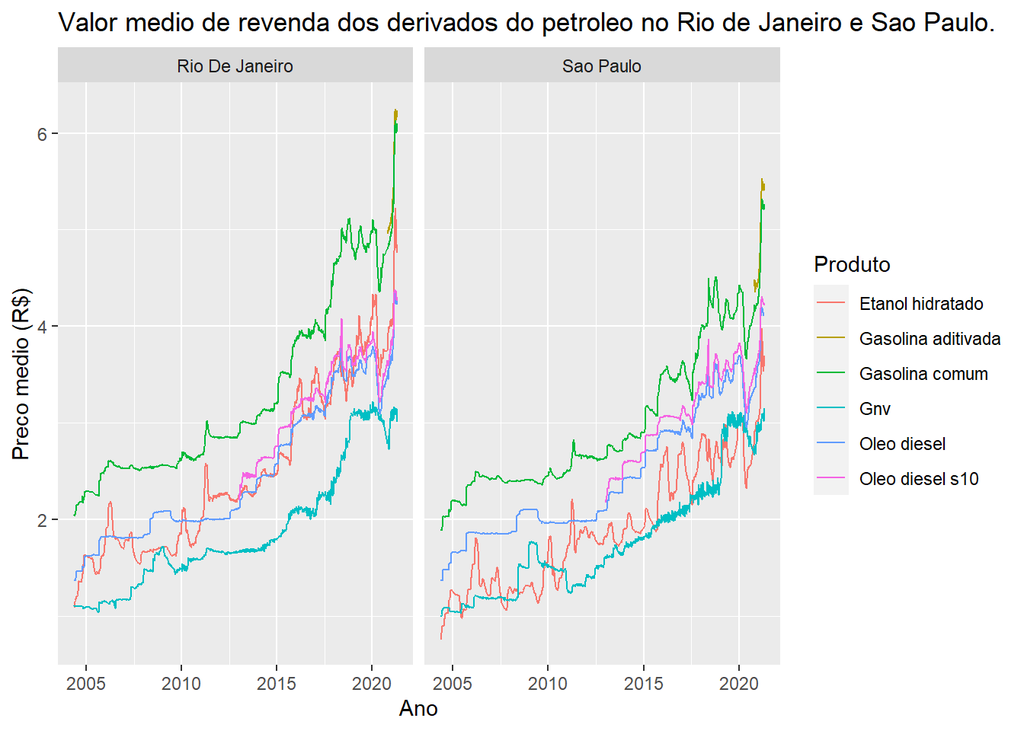

```r
df_sem_glp %>% filter(
  estado == "Rio De Janeiro" | estado == "Sao Paulo"
  ) %>% ggplot(aes(
    x = data_inicial,
    y = preco_medio_revenda,
    color = produto,
  )) + geom_line() + facet_wrap(~estado) +
  labs(
    title = "Valor medio de revenda dos derivados do petroleo no Rio de Janeiro e Sao Paulo.",
    x = "Ano",
    y = "Preco medio (R$)",
    color = "Produto"
  )
```

# 4 Referências

- [Como são formados os preços, Petrobras](https://precos.petrobras.com.br/web/precos-dos-combustiveis/w/gasolina/br)
- [Preços de Revenda e de Distribuição de Combustíveis, Governo Federal](https://www.gov.br/anp/pt-br/assuntos/precos-e-defesa-da-concorrencia/precos/precos-revenda-e-de-distribuicao-combustiveis)